# SQL for R Users

Jae Yeon Kim

- Special thanks to Jacob Coblnetz (@Jacob_Coblnetz) for sharing his slides on the SQL workshop used at MIT.

# 1 Motivation

> 1. Designed vs. Found Data ([Salganik 2017](https://www.bitbybitbook.com/))
- Designed (e.g., Survey data, Experimental data; Small/medium size) vs.
- Found Data (e.g., Administrative data, Corporate data; Often Large)
> 2. The varieties of the datasets ([Pradeep and Moy 2015](https://rstudio-pubs-static.s3.amazonaws.com/72295_692737b667614d369bd87cb0f51c9a4b.html)):
- Small (what most of you have worked with)
- Medium (1-2 GB)
- Large (2 - 10 GB)
- Very large (> 10 GB)
> 3. Recipes for big data:
- Slice and dice: `read.csv("file_address", nrows = 20` or `data.table::fread()`
- Parallel processing: (`partition`, `summarize`, and `collect` from the `multidplyr` package)
- Multiple sessions: `bigmemory::read.big.matrix()` or `ff::read.csv.ffdf()`
- Distributed filesystem: [RHadoop](https://github.com/RevolutionAnalytics/RHadoop/wiki). [Almost an only option for a dataset larger than 5TB](https://www.chrisstucchio.com/blog/2013/hadoop_hatred.html).
- SQL: Extracting data from a database. SQL is a staple tool in the non-academic world to perform this task. Key idea: Local dataframe -> Database. The focus of today’s workshop

# 2 What is SQL?

- Structured Query Language. Called SEQUEL and developed by IBM Corporation in the 1970s
- Remains the standard language for a relational database management system.
- It’s a DECLARATIVE language ([compute what you want to compute not how to compute it](https://www.sqlite.org/queryplanner.html))
- Its main job is to define and query databases (i.e., two-dimensional tables).
- Great for keeping data type integrity, updating data frequently, joining different data sources, and doing quick data analyses

# 3 Learning objectives

> - Embracing a new mindset: from ownership (opening CSVs in your laptop) to access (accessing data stored in the database)
> - Learning how to access and query a database in R in a tidy way
- SQL and R

| SQL | R |
| --- | --- |
| SELECT | select() for columns, mutate() for expressions, summarise() for aggregates |
| FROM | which data frame |
| WHERE | filter() |
| GROUP BY | group_by() |
| HAVING | filter() after group_by() |
| ORDER BY | arrange() |
| LIMIT | head() |

# 4 Setup

- `pacman::p_load()` reduces steps for installing and loading several packages simultaneously.

```r
rm(list = ls())

if (!require("pacman")) install.packages("pacman")
pacman::p_load(
 tidyverse, # tidyverse packages
 conflicted, # an alternative conflict resolution strategy
 dbplyr, # to use database with dplyr
 DBI, # for using SQL queries
 RSQLite, # for SQLite
 odbc, # backend engine; open data connectivity driver
 RPostgres, # PostgreSQL
 glue, # for gluing strings to data
 tidyquery, # sqldf alternative
 nycflights13 # for test data
)

# Resolving conflicting functions
conflict_prefer("filter", "dplyr")
```

```
## [conflicted] Will prefer dplyr::filter over any other package
```

```r
conflict_prefer("sql", "dplyr")
```

```
## [conflicted] Will prefer dplyr::sql over any other package
```

# 5 Data sets

We use [the flight on-time performance data](https://www.transtats.bts.gov/DL_SelectFields.asp?Table_ID=236) from the Bureau of Transpiration Statistics of the U.S. government. The data goes back to 1987 and its size is more than 20 gigabytes. For practice, we only use a small subset of the original data (flight data departing NYC in 2013) provided by RStudio.

## 5.1 Connect to the database

- This part draws heavily on the `dbplyr` package vignette.
- The `DBI` package provides a client-side interface that allows `dplyr` to work with databases. DBI is automatically installed when you installed `dbplyr`. However, you need to install a specific backend engine (a tool for communication between R and a database management system) for the database (e.g., `RMariaDB`, `RPostgres`, `RSQLite`, `obdc`, `bigrquery`). In this workshop, we use SQLite because it is the easiest to get started with. Personally, I love PostgreSQL because it’s an open-source and also powerful to do [many amazing things](https://www.postgresql.org/docs/current/functions.html) (e.g., text mining, geospatial analysis).
- If you want to connect to the database not manually, you can use the Connections interface in RStudio.
- Here’s [some information](https://db.rstudio.com/dbi) on the historical background of the package.

```r
# Define a backend engine

drv <- RSQLite::SQLite()

# Create an empty in-memory database

con <- DBI::dbConnect(drv,
                      dbname = ":memory:")

#con <- DBI::dbConnect(RMariaDB::MariaDB(),
 # host = "database.rstudio.com",
 # user = "hadley",
 # password = rstudioapi::askForPassword("Database password")
#)

# Copy a local data frame to a DBI backend

copy_to(dest = con, # remote data source
        df = flights) # a local dataframe

copy_to(dest = con, # remote data source
        df = airports) # a local dataframe

# Note that we didn't load the data.

src_dbi(con)
```

```
## src:  sqlite 3.30.1 [:memory:]
## tbls: airports, flights, sqlite_stat1, sqlite_stat4
```

Show the list of tables.

```r
# Return the name of the tables
dbListTables(con)
```

```
## [1] "airports"     "flights"      "sqlite_stat1" "sqlite_stat4"
```

## 5.2 Query using dbplyr

- The `tbl` object is lazily evaluated; It doesn’t pull the data until you explicitly ask for it.

```r
# Select all columns from flights table and show the first ten rows

dbGetQuery(con, "SELECT * FROM flights;") %>%
  head(10)
```

|  | year | month | day | dep_time | sched_dep_time | dep_delay | arr_time | sched_arr_time | arr_delay | carrier | flight | tailnum | origin | dest | air_time | distance | hour | minute | time_hour |
| --- | --- | --- | --- | --- | --- | --- | --- | --- | --- | --- | --- | --- | --- | --- | --- | --- | --- | --- | --- |
| 1 | 2013 | 1 | 1 | 517 | 515 | 2 | 830 | 819 | 11 | UA | 1545 | N14228 | EWR | IAH | 227 | 1400 | 5 | 15 | 1357034400 |
| 2 | 2013 | 1 | 1 | 533 | 529 | 4 | 850 | 830 | 20 | UA | 1714 | N24211 | LGA | IAH | 227 | 1416 | 5 | 29 | 1357034400 |
| 3 | 2013 | 1 | 1 | 542 | 540 | 2 | 923 | 850 | 33 | AA | 1141 | N619AA | JFK | MIA | 160 | 1089 | 5 | 40 | 1357034400 |
| 4 | 2013 | 1 | 1 | 544 | 545 | -1 | 1004 | 1022 | -18 | B6 | 725 | N804JB | JFK | BQN | 183 | 1576 | 5 | 45 | 1357034400 |
| 5 | 2013 | 1 | 1 | 554 | 600 | -6 | 812 | 837 | -25 | DL | 461 | N668DN | LGA | ATL | 116 | 762 | 6 | 0 | 1357038000 |
| 6 | 2013 | 1 | 1 | 554 | 558 | -4 | 740 | 728 | 12 | UA | 1696 | N39463 | EWR | ORD | 150 | 719 | 5 | 58 | 1357034400 |
| 7 | 2013 | 1 | 1 | 555 | 600 | -5 | 913 | 854 | 19 | B6 | 507 | N516JB | EWR | FLL | 158 | 1065 | 6 | 0 | 1357038000 |
| 8 | 2013 | 1 | 1 | 557 | 600 | -3 | 709 | 723 | -14 | EV | 5708 | N829AS | LGA | IAD | 53 | 229 | 6 | 0 | 1357038000 |
| 9 | 2013 | 1 | 1 | 557 | 600 | -3 | 838 | 846 | -8 | B6 | 79 | N593JB | JFK | MCO | 140 | 944 | 6 | 0 | 1357038000 |
| 10 | 2013 | 1 | 1 | 558 | 600 | -2 | 753 | 745 | 8 | AA | 301 | N3ALAA | LGA | ORD | 138 | 733 | 6 | 0 | 1357038000 |

```r
# Select dep_delay and arr_delay from flights table and show the first ten rows

dbGetQuery(con, "SELECT dep_delay, arr_delay FROM flights;") %>%
  head(10)
```

|  | dep_delay | arr_delay |
| --- | --- | --- |
| 1 | 2 | 11 |
| 2 | 4 | 20 |
| 3 | 2 | 33 |
| 4 | -1 | -18 |
| 5 | -6 | -25 |
| 6 | -4 | 12 |
| 7 | -5 | 19 |
| 8 | -3 | -14 |
| 9 | -3 | -8 |
| 10 | -2 | 8 |

```r
# Select dep_delay and arr_delay from flights table, show the first ten rows, then turn the result into a tibble.

dbGetQuery(con, "SELECT dep_delay, arr_delay FROM flights;") %>%
  head(10) %>%
  as.tibble()
```

| dep_delay | arr_delay |
| --- | --- |
| 2 | 11 |
| 4 | 20 |
| 2 | 33 |
| -1 | -18 |
| -6 | -25 |
| -4 | 12 |
| -5 | 19 |
| -3 | -14 |
| -3 | -8 |
| -2 | 8 |

# 6 Tidy-way: dplyr -> SQL

One of the recent developments in the tidyverse. Working with a database using the `dplyr` syntax.

These examples are from [the vignette](https://cran.r-project.org/web/packages/dbplyr/vignettes/translation-verb.html) of the `dbplyr` package.

```r
# tbl select tables
flights <- con %>% tbl("flights")
airports <- con %>% tbl("airports")
```

## 6.1 `select` = `SELECT`

```r
# Set to dplyr
conflict_prefer("filter", "dplyr")
```

```
## [conflicted] Removing existing preference
```

```
## [conflicted] Will prefer dplyr::filter over any other package
```

```r
flights %>%
  select(contains("delay")) %>%
  show_query()
```

```
## <SQL>
## SELECT `dep_delay`, `arr_delay`
## FROM `flights`
```

## 6.2 `mutate` = `SELECT` `AS`

```r
flights %>%
  select(distance, air_time) %>%
  mutate(speed = distance / (air_time / 60)) %>%
  show_query()
```

```
## <SQL>
## SELECT `distance`, `air_time`, `distance` / (`air_time` / 60.0) AS `speed`
## FROM `flights`
```

## 6.3 `filter` = `WHERE`

```r
flights %>%
  filter(month == 1, day == 1) %>%
  show_query()
```

```
## <SQL>
## SELECT *
## FROM `flights`
## WHERE ((`month` = 1.0) AND (`day` = 1.0))
```

- Note that R and SQL operators are not exactly alike. R uses `!=` for `Not equal to`. SQL uses `<>` or `!=`. Also, some of SQL comparison operators are more intuitive than their R counterparts (`WHERE student_ID BETWEEN 1 and 100` `WHERE first_name LIKE 'Jae'`).

## 6.4 `arrange` = `ORDER BY`

```r
flights %>%
  arrange(carrier, desc(arr_delay)) %>%
  show_query()
```

```
## <SQL>
## SELECT *
## FROM `flights`
## ORDER BY `carrier`, `arr_delay` DESC
```

## 6.5 `summarise` = `SELECT` `AS` and `group by` = `GROUP BY`

```r
flights %>%
  group_by(month, day) %>%
  summarise(delay = mean(dep_delay)) %>%
  show_query()
```

```
## <SQL>
```

```
## SELECT `month`, `day`, AVG(`dep_delay`) AS `delay`
## FROM `flights`
## GROUP BY `month`, `day`
```

## 6.6 Data visualization

This part is from [RStudio’s DB best practices](https://db.rstudio.com/best-practices/visualization/).

- A typical ggplot2

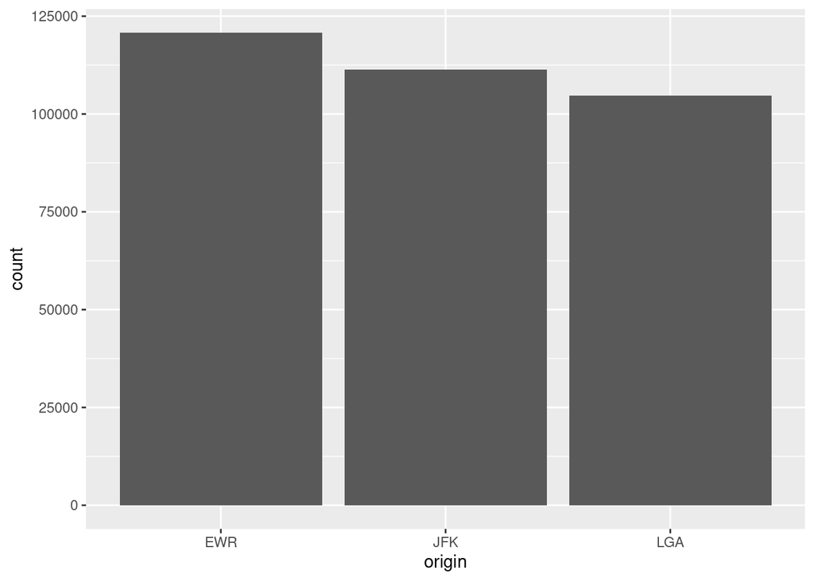

```r
ggplot(flights) +
  geom_bar(aes(x = origin), stat = "count")
```

- Best practice: transforming data -> plotting results in R
- `collect()` is used to pull the data. Depending on the data size, it may take a long time to run.

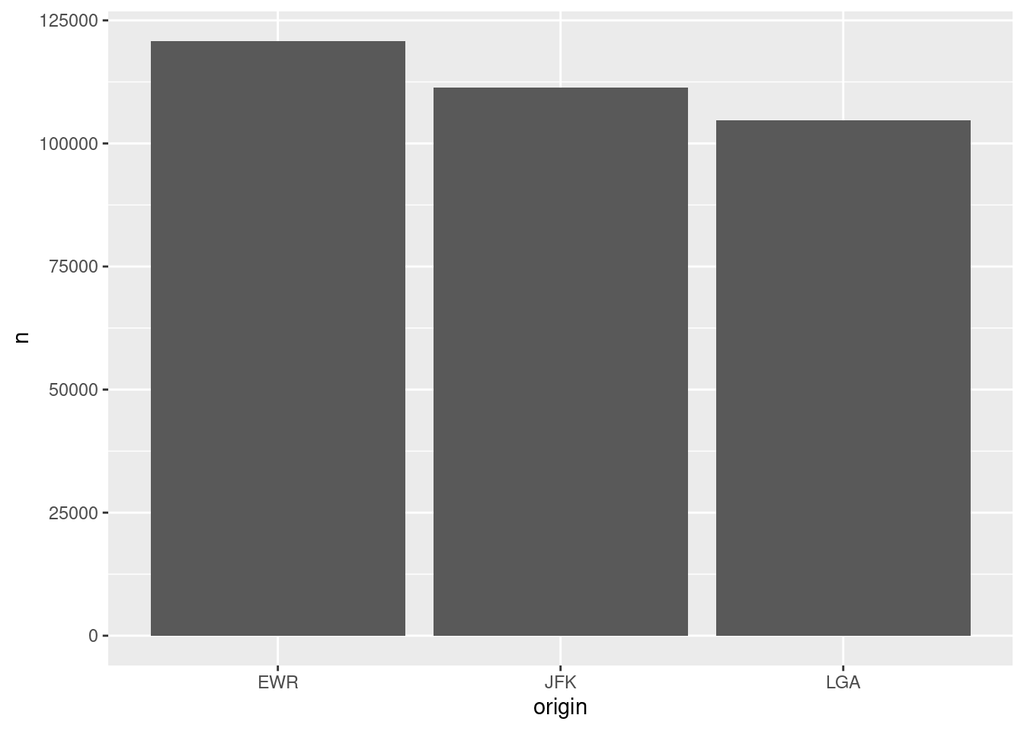

```r
df <- flights %>%
  group_by(origin) %>%
  tally() %>%
  collect()

# Shifted from geom_bar() to geom_col() because the heights of bar plots were calculated by tally()

ggplot(df) +
  geom_col(aes(x = origin, y = n))
```

# 7 SQL-way: SQL -> dplyr

Remember the `dbGetQuery()` function from `DBI` package?

## 7.1 `select` = `SELECT`

```r
dbGetQuery(con, "SELECT dep_delay, arr_delay FROM flights")
```

| dep_delay | arr_delay |
| --- | --- |
| 2 | 11 |
| 4 | 20 |
| 2 | 33 |
| -1 | -18 |
| -6 | -25 |
| -4 | 12 |
| -5 | 19 |
| -3 | -14 |
| -3 | -8 |
| -2 | 8 |

[output cut: 9990 more lines]

## 7.2 `mutate` = `SELECT` `AS`

Also, note that you can combine functions from `DBI` and `dplyr`.

```r
  # DBI
dbGetQuery(con, "SELECT distance, air_time, distance / air_time / 60.0 AS speed
FROM flights") %>%
  # dplyr
  arrange(desc(air_time))
```

| distance | air_time | speed |
| --- | --- | --- |
| 4963 | 695 | 0.11901679 |
| 4983 | 691 | 0.12018813 |
| 4983 | 686 | 0.12106414 |
| 4983 | 686 | 0.12106414 |
| 4983 | 683 | 0.12159590 |
| 4983 | 679 | 0.12231222 |
| 4963 | 676 | 0.12236193 |
| 4983 | 676 | 0.12285503 |
| 4983 | 675 | 0.12303704 |
| 4963 | 671 | 0.12327372 |

[output cut: 9990 more lines]

## 7.3 `filter` = `WHERE`

```r
dbGetQuery(con, "
SELECT *
FROM flights
WHERE month = 1.0 AND day = 1.0
")
```

| year | month | day | dep_time | sched_dep_time | dep_delay | arr_time | sched_arr_time | arr_delay | carrier | flight | tailnum | origin | dest | air_time | distance | hour | minute | time_hour |
| --- | --- | --- | --- | --- | --- | --- | --- | --- | --- | --- | --- | --- | --- | --- | --- | --- | --- | --- |
| 2013 | 1 | 1 | 517 | 515 | 2 | 830 | 819 | 11 | UA | 1545 | N14228 | EWR | IAH | 227 | 1400 | 5 | 15 | 1357034400 |
| 2013 | 1 | 1 | 533 | 529 | 4 | 850 | 830 | 20 | UA | 1714 | N24211 | LGA | IAH | 227 | 1416 | 5 | 29 | 1357034400 |
| 2013 | 1 | 1 | 542 | 540 | 2 | 923 | 850 | 33 | AA | 1141 | N619AA | JFK | MIA | 160 | 1089 | 5 | 40 | 1357034400 |
| 2013 | 1 | 1 | 544 | 545 | -1 | 1004 | 1022 | -18 | B6 | 725 | N804JB | JFK | BQN | 183 | 1576 | 5 | 45 | 1357034400 |
| 2013 | 1 | 1 | 554 | 600 | -6 | 812 | 837 | -25 | DL | 461 | N668DN | LGA | ATL | 116 | 762 | 6 | 0 | 1357038000 |
| 2013 | 1 | 1 | 554 | 558 | -4 | 740 | 728 | 12 | UA | 1696 | N39463 | EWR | ORD | 150 | 719 | 5 | 58 | 1357034400 |
| 2013 | 1 | 1 | 555 | 600 | -5 | 913 | 854 | 19 | B6 | 507 | N516JB | EWR | FLL | 158 | 1065 | 6 | 0 | 1357038000 |
| 2013 | 1 | 1 | 557 | 600 | -3 | 709 | 723 | -14 | EV | 5708 | N829AS | LGA | IAD | 53 | 229 | 6 | 0 | 1357038000 |
| 2013 | 1 | 1 | 557 | 600 | -3 | 838 | 846 | -8 | B6 | 79 | N593JB | JFK | MCO | 140 | 944 | 6 | 0 | 1357038000 |
| 2013 | 1 | 1 | 558 | 600 | -2 | 753 | 745 | 8 | AA | 301 | N3ALAA | LGA | ORD | 138 | 733 | 6 | 0 | 1357038000 |

[output cut: 832 more lines]

## 7.4 `arrange` = `ORDER BY`

```r
dbGetQuery(con, "
SELECT *
FROM flights
ORDER BY carrier, arr_delay DESC
")
```

| year | month | day | dep_time | sched_dep_time | dep_delay | arr_time | sched_arr_time | arr_delay | carrier | flight | tailnum | origin | dest | air_time | distance | hour | minute | time_hour |
| --- | --- | --- | --- | --- | --- | --- | --- | --- | --- | --- | --- | --- | --- | --- | --- | --- | --- | --- |
| 2013 | 2 | 16 | 757 | 1930 | 747 | 1013 | 2149 | 744 | 9E | 3798 | N8940E | JFK | CLT | 85 | 541 | 19 | 30 | 1361059200 |
| 2013 | 7 | 24 | 1525 | 815 | 430 | 1808 | 1030 | 458 | 9E | 3538 | N927XJ | JFK | MSP | 150 | 1029 | 8 | 15 | 1374667200 |
| 2013 | 7 | 10 | 2054 | 1459 | 355 | 102 | 1801 | 421 | 9E | 3325 | N937XJ | JFK | DFW | 191 | 1391 | 14 | 59 | 1373479200 |
| 2013 | 11 | 27 | 1503 | 815 | 408 | 1628 | 952 | 396 | 9E | 2906 | N930XJ | JFK | BUF | 56 | 301 | 8 | 15 | 1385557200 |
| 2013 | 12 | 14 | 1425 | 825 | 360 | 1604 | 938 | 386 | 9E | 2901 | N936XJ | JFK | BOS | 34 | 187 | 8 | 25 | 1387026000 |
| 2013 | 2 | 27 | 1529 | 845 | 404 | 1639 | 1015 | 384 | 9E | 3405 | N922XJ | JFK | DCA | 49 | 213 | 8 | 45 | 1361970000 |
| 2013 | 7 | 22 | 2216 | 1620 | 356 | 116 | 1853 | 383 | 9E | 3341 | N903XJ | JFK | DTW | 88 | 509 | 16 | 20 | 1374523200 |
| 2013 | 6 | 25 | 1421 | 805 | 376 | 1602 | 950 | 372 | 9E | 3611 | N8458A | JFK | PIT | 64 | 340 | 8 | 5 | 1372161600 |
| 2013 | 1 | 25 | 15 | 1815 | 360 | 208 | 1958 | 370 | 9E | 4019 | N8646A | JFK | RIC | 56 | 288 | 18 | 15 | 1359154800 |
| 2013 | 3 | 1 | 1449 | 855 | 354 | 1701 | 1104 | 357 | 9E | 3552 | N937XJ | JFK | DTW | 90 | 509 | 8 | 55 | 1362142800 |

[output cut: 9990 more lines]

## 7.5 `summarise` = `SELECT` `AS` and `group by` = `GROUP BY`

```r
dbGetQuery(con, "
SELECT month, day, AVG(dep_delay) AS delay
FROM flights
GROUP BY month, day
")
```

| month | day | delay |
| --- | --- | --- |
| 1 | 1 | 11.54892601 |
| 1 | 2 | 13.85882353 |
| 1 | 3 | 10.98783186 |
| 1 | 4 | 8.95159516 |
| 1 | 5 | 5.73221757 |
| 1 | 6 | 7.14801444 |
| 1 | 7 | 5.41720430 |
| 1 | 8 | 2.55307263 |
| 1 | 9 | 2.27647715 |
| 1 | 10 | 2.84499462 |

[output cut: 355 more lines]

# 8 What we can’t do

Check out the issue section of [`queryparser`](https://github.com/ianmcook/queryparser) and that of [`tidyquery`](https://github.com/ianmcook/tidyquery/issues) to see the latest developments.

**Limitations**

```
- Subqueries
- Unions
- Implict join notation
- Joins of three plus tables
- WITH clause
- OVER expressions
- Non-ASCII characters in queries
```

**Non-Goals**

```
- Translate other types of SQL statements (such as `INSERT` or `UPDATE`) and other more complex tasks (e.g., efficient process large batches of queries)
```

# 9 References

- R Studio, [Database using R](https://db.rstudio.com/)
- Ian Cook, [“Bridging the Gap between SQL and R”](https://github.com/ianmcook/rstudioconf2020/blob/master/bridging_the_gap_between_sql_and_r.pdf) rstudio::conf 2020 slides
- Data Carpentry contributors, [SQL database and R](https://datacarpentry.org/R-ecology-lesson/05-r-and-databases.html), Data Carpentry, September 10, 2019.
- [Introduction to dbplyr](https://cran.r-project.org/web/packages/dbplyr/vignettes/dbplyr.html)
- Benjamin S. Baumer, Daniel T. Kaplan, and Nicholas J. Horton, [Moden Data Science with R, 2nd ed.](https://beanumber.github.io/mdsr2e/), CRC Press, 2020-01-03.
- Josh Erickson, [SQL in R](http://dept.stat.lsa.umich.edu/~jerrick/courses/stat701/notes/sql.html), STAT 701, University of Michigan
- [Deborah Nolan](https://www.stat.berkeley.edu/~nolan/), [STAT 133 class notes](https://www.stat.berkeley.edu/~nolan/stat133/Fall05/lectures/), University of California, Berkeley, Fall 2005
- [Kane, Michael J](https://medicine.yale.edu/profile/michael_kane/), “Strategies for Exploring a 12 Gigabyte Data Set: Airline Flight Delays,” Invited book chapter in Data Science in R: A Case Studies Approach to Computational Reasoning and Problem Solving, 2015.
- Kane, Michael J., John Emerson, and Stephen Weston. [“Scalable strategies for computing with massive data.”](http://www.stat.yale.edu/~jay/EmersonMaterials/ScalableStrategies.pdf) Journal of Statistical Software 55.14 (2013): 1-19.
- Eduardo Arino de la Rubia, [“Multicore Data Science with R and Python”](https://blog.dominodatalab.com/multicore-data-science-r-python/), Domino Data Lab, May 22, 2017.